# Building buy/sell strategies based on top investors behaviour

Now doing the same for the period 2018-2021:

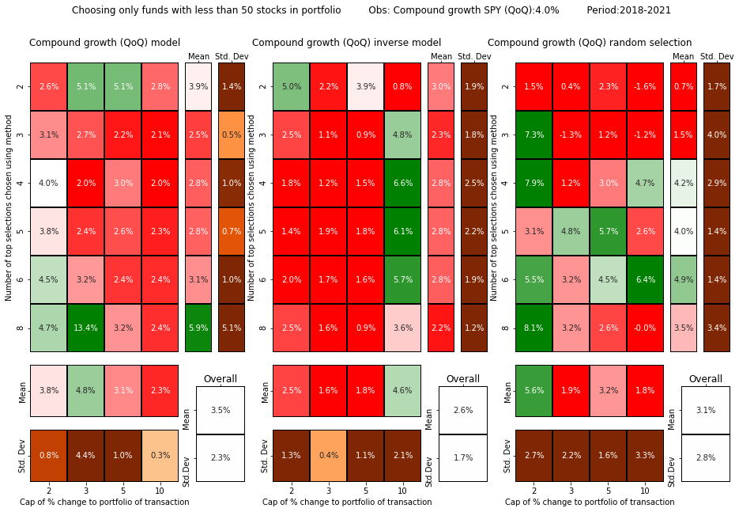

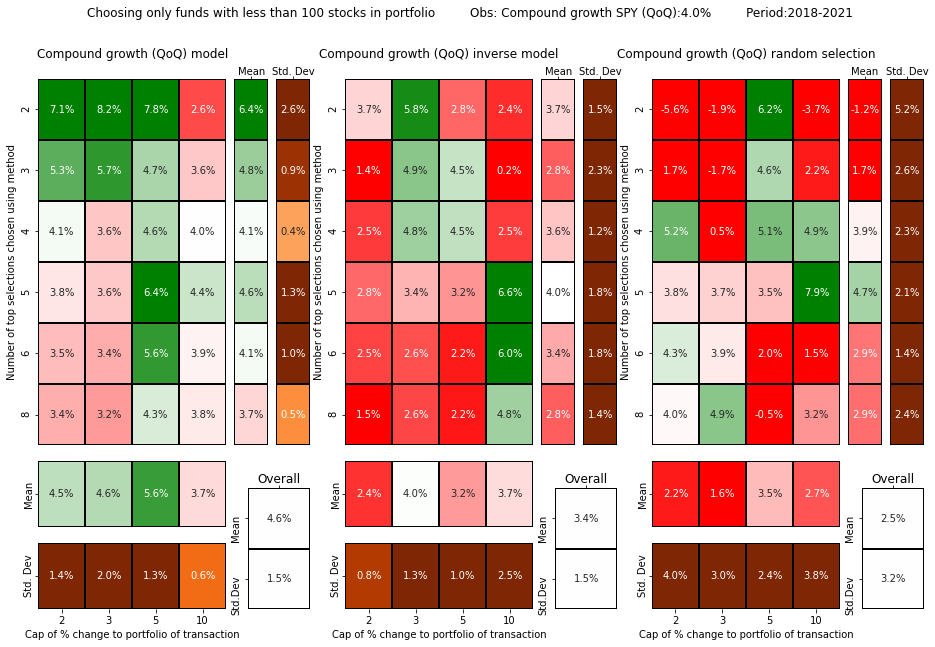

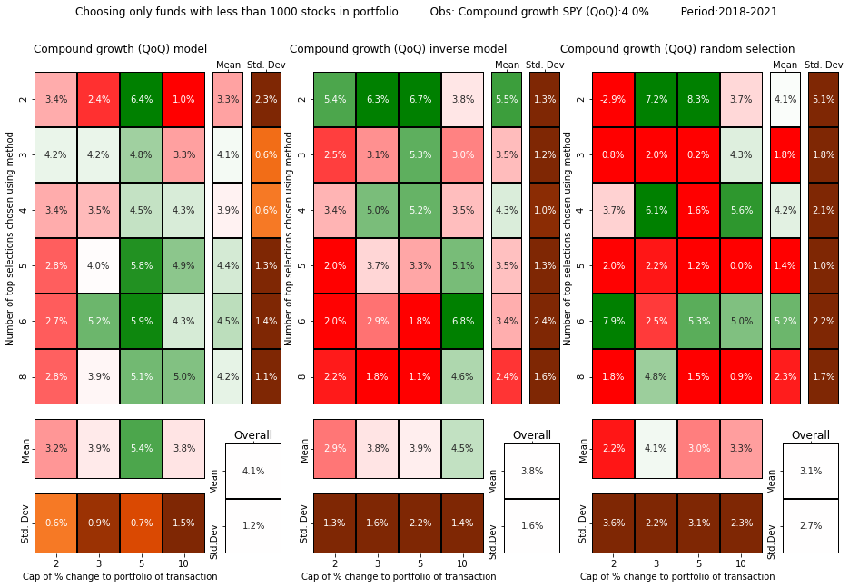

```python
starting_date=2018
ending_date=2022

plot_sensitibity_compound_growth(minimum_percent_list,max_stocks,top_to_select,perc_increase_cap,metric,starting_date,ending_date)
```

The main conclusions when analyzing the compound growth on the period of 2018-2021 and comparing to the previous period:

1. Although the stocks selected by the model seemed to overperform the ones selected by the inverse model, the difference was very low and not as well defined as in the first method.
2. The performance was not as well defined and predictable as the previous analyses: there was no better tendency in selecting the top 2-4 stocks as seen before.
3. The cap of 5% was the one which performed the best here.
4. Again, no clear advantage was seen in filtering funds with more or less stocks in the portfolio.
5. Overall, when compared to method 1, method 2 seemed to be much more subject to oscillations depending on the parameters chosen. Furthermore, the differences between the method and inverse method were much less clear when using method 2 than using method 1.
6. Method 1 was slightly less sensitive to changes in the parameters.

Finally, selecting the best ranges of parameter values for both methods for the entire period, the result is shown below.

Althought these are the parameters that better seemed to best select the stocks (in both the periods analyzed), it is not possible to say that these values are likely to happen in the future. As we saw, the methods were very sensitive to oscillations with just small changes to the parameters and selecting the ones that performed best in 2013-2017 did not necessarily provide the best results in 2018-2021.

As such, depending solely on this analysis could be risky, as oscillations were very high and returns not very reliable. The analysis, however, is useful to point the investor to potential good investments (or bad investments when using the reverse method) and can be used as a screening tool, showing the top recommendations of the model which could be further analyzed using other criteria.

#### Method 1 - Net Buy/Sells

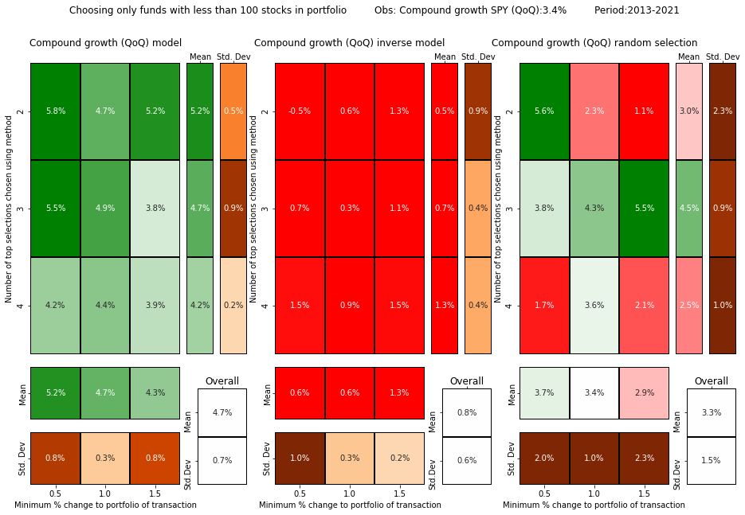

```python
minimum_percent_list=[.5,1,1.5]
max_stocks=[100]
top_to_select=[2,3,4]
perc_increase_cap=[5]
starting_date=2013
ending_date=2022
metric=['Net Buy/Sells','Net % change']
plot_sensitibity_compound_growth(minimum_percent_list,max_stocks,top_to_select,perc_increase_cap,metric,starting_date,ending_date)
```

#### Method 2 - Net % change

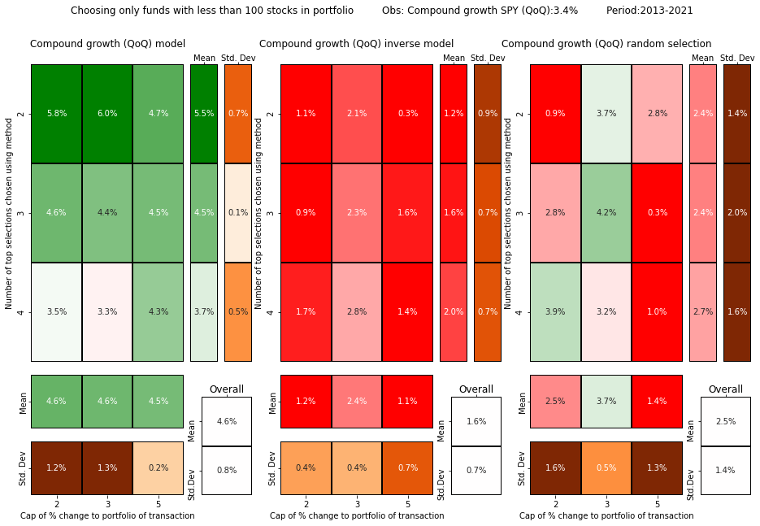

```python
minimum_percent_list=[.2]
max_stocks=[100]
top_to_select=[2,3,4]
perc_increase_cap=[2,3,5]
starting_date=2013
ending_date=2022
metric=['Net % change']
plot_sensitibity_compound_growth(minimum_percent_list,max_stocks,top_to_select,perc_increase_cap,metric,starting_date,ending_date)
```

# 7 The stocks selected by the method

As a final item, some parameters of each method are selected to show which are the stocks bought and sold each quarter according to the methods.

## 7.1 Net Buy/Sells

For the first method, the following parameters were used:

1. Minimum % change to consider transaction: 0.5%
2. Maximum stocks in fund: 100
3. Top stocks to select from method: 3

```python
def get_stocks_sold_bought_method(minimum_percent,max_stocks,top_to_select,perc_increase_cap,metric,starting_date,ending_date):

    data= read_data_excel()


    filter_percent_port=minimum_percent
    perc_increase_cap=perc_increase_cap
    max_number_of_stocks_in_port=max_stocks
    top_to_select=top_to_select


    data_filt=data_filter_and_process(data,filter_percent_port,max_number_of_stocks_in_port,perc_increase_cap)
    data_filt[(data_filt['year']>=starting_date)&(data_filt['year']<ending_date)]

    df_transactions=generate_df_transaction_metrics(data_filt)
    comp_growth_spy,comp_growth_p,comp_growth_n,comp_growth_rand,bought_by_quarter_method,sold_by_quarter_method=simulate_compound_growth(df_transactions,[starting_date,ending_date],metric,0,top_to_select,0,0)
    return comp_growth_spy,comp_growth_p,comp_growth_n,bought_by_quarter_method,sold_by_quarter_method
```

```python
comp_spy,comp_p,comp_n,buy_df,sell_df=get_stocks_sold_bought_method(0.5,100,3,4,['Net Buy/Sells','Net % change'],2013,2022)
md('Compound growth spy:**{:.2f}%** -    Compound growth method:**{:.2f}%** -    Compound growth inverse method:**{:.2f}%**'.format(comp_spy,comp_p,comp_n))
```

Compound growth spy:**3.44%** - Compound growth method:**5.35%** - Compound growth inverse method:**0.61%**

### METHOD 1 - STOCKS TO BUY

```python
buy_df
```

|  | 2013 Q1 | 2013 Q2 | 2013 Q3 | 2013 Q4 | 2014 Q1 | 2014 Q2 | 2014 Q3 | 2014 Q4 | 2015 Q1 | 2015 Q2 | 2015 Q3 | 2015 Q4 | 2016 Q1 | 2016 Q2 | 2016 Q3 | 2016 Q4 | 2017 Q1 | 2017 Q2 | 2017 Q3 | 2017 Q4 | 2018 Q1 | 2018 Q2 | 2018 Q3 | 2018 Q4 | 2019 Q1 | 2019 Q2 | 2019 Q3 | 2019 Q4 | 2020 Q1 | … |
| --- | --- | --- | --- | --- | --- | --- | --- | --- | --- | --- | --- | --- | --- | --- | --- | --- | --- | --- | --- | --- | --- | --- | --- | --- | --- | --- | --- | --- | --- | --- |
| 0 | AAPL - Apple Inc.(Net:4.0) Return:14.1% | ESRX - Express Scripts(Net:4.0) Return:0.7% | MSFT - Microsoft Corp.(Net:4.0) Return:-0.5% | WU - Western Union C(Net:3.0) Return:0.0% | LBTYK - Liberty Global (Net:4.0) Return:-2.6% | LE - Lands End Inc.(Net:3.0) Return:37.8% | EBAY - eBay Inc.(Net:3.0) Return:1.4% | IBM - International B(Net:4.0) Return:10.4% | MSFT - Microsoft Corp.(Net:5.0) Return:-4.2% | GM - General Motors(Net:3.0) Return:11.5% | LNG - Cheniere Energy(Net:3.0) Return:-44.8% | APA - APA Corp.(Net:2.0) Return:56.2% | BAC - Bank of America(Net:4.0) Return:8.7% | SHPG - Shire plc(Net:3.0) Return:-6.3% | KMI - Kinder Morgan(Net:3.0) Return:10.4% | CVS - CVS Health Corp(Net:3.0) Return:2.5% | GOOGL - Alphabet Inc.(Net:3.0) Return:-1.7% | FB - Facebook Inc.(Net:4.0) Return:4.7% | DD - DuPont de Nemou(Net:3.0) Return:0.3% | TWX - Time Warner Inc(Net:3.0) Return:0.5% | FB - Facebook Inc.(Net:10.0) Return:-2.3% | T - AT&T Inc.(Net:4.0) Return:-3.8% | GE - General Electri(Net:3.0) Return:17.6% | FB - Facebook Inc.(Net:8.0) Return:10.6% | PCG - PG&E Corp.(Net:3.0) Return:-8.0% | BMY - Bristol-Myers S(Net:4.0) Return:26.0% | AMZN - Amazon.com Inc.(Net:5.0) Return:23.1% | VIAC - ViacomCBS Inc.(Net:6.0) Return:-51.8% | FB - Facebook Inc.(Net:7.0) Return:27.8% | … |
| 1 | WU - Western Union C(Net:4.0) Return:11.5% | CTSH - Cognizant Techn(Net:3.0) Return:27.1% | MU - Micron Technolo(Net:2.0) Return:31.6% | APA - APA Corp.(Net:2.0) Return:11.1% | LH - Laboratory Corp(Net:3.0) Return:4.5% | C - Citigroup Inc.(Net:3.0) Return:9.2% | IBM - International B(Net:2.0) Return:-1.4% | KMT - Kennametal Inc.(Net:3.0) Return:11.4% | AXP - American Expres(Net:3.0) Return:-0.1% | TGNA - TEGNA Inc.(Net:3.0) Return:2.4% | GE - General Electri(Net:3.0) Return:-7.0% | EMC - EMC Corp.(Net:2.0) Return:-4.8% | SYF - Synchrony Finan(Net:3.0) Return:-3.6% | STX - Seagate Technol(Net:3.0) Return:19.7% | BMY - Bristol-Myers S(Net:2.0) Return:-7.1% | AMZN - Amazon.com Inc.(Net:3.0) Return:14.5% | GM - General Motors(Net:2.0) Return:4.7% | COF - Capital One Fin(Net:3.0) Return:3.6% | GOOG - Alphabet Inc. C(Net:3.0) Return:2.6% | AMZN - Amazon.com Inc.(Net:2.0) Return:12.9% | AIG - American Intern(Net:5.0) Return:-0.9% | C - Citigroup Inc.(Net:3.0) Return:-5.0% | COOP - Mr. Cooper Grou(Net:3.0) Return:-2.0% | EBAY - eBay Inc.(Net:4.0) Return:2.0% | MU - Micron Technolo(Net:3.0) Return:13.1% | UNH - United Health G(Net:4.0) Return:3.4% | CRM - Salesforce.com(Net:4.0) Return:16.1% | DD - DuPont de Nemou(Net:3.0) Return:-15.6% | JPM - JPMorgan Chase (Net:5.0) Return:18.0% | … |
| 2 | BP - BP plc(Net:3.0) Return:-1.6% | WU - Western Union C(Net:3.0) Return:-2.7% | APD - Air Products & (Net:2.0) Return:8.5% | ORCL - Oracle Corp.(Net:2.0) Return:9.5% | MSFT - Microsoft Corp.(Net:2.0) Return:10.0% | ESRX - Express Scripts(Net:3.0) Return:8.1% | LNG - Cheniere Energy(Net:2.0) Return:6.7% | LNG - Cheniere Energy(Net:2.0) Return:1.2% | HAL - Halliburton Co.(Net:3.0) Return:-9.6% | AXP - American Expres(Net:2.0) Return:-11.7% | AA - Alcoa Corp.(Net:3.0) Return:-5.1% | RTX - Raytheon Techno(Net:2.0) Return:18.6% | RACE - Ferrari NV(Net:2.0) Return:12.1% | CHTR - Charter Communi(Net:2.0) Return:4.9% | SRCL - Stericycle Inc.(Net:2.0) Return:4.3% | PNC - PNC Financial S(Net:2.0) Return:-2.6% | CMCSA - Comcast Corp.(Net:2.0) Return:7.1% | GE - General Electri(Net:3.0) Return:-24.9% | MDLZ - Mondelez Intern(Net:3.0) Return:2.1% | SJM - J.M. Smucker Co(Net:2.0) Return:-6.0% | KMI - Kinder Morgan(Net:3.0) Return:9.0% | GE - General Electri(Net:3.0) Return:-29.1% | UNP - Union Pacific(Net:2.0) Return:12.6% | LEN - Lennar Corp.(Net:3.0) Return:10.3% | BAC - Bank of America(Net:3.0) Return:-3.6% | GOOG - Alphabet Inc. C(Net:3.0) Return:10.3% | NFLX - Netflix Inc.(Net:3.0) Return:34.7% | EBAY - eBay Inc.(Net:3.0) Return:10.9% | MU - Micron Technolo(Net:3.0) Return:5.4% | … |
| 3 | SPY - Return: 3.3% | SPY - Return: 5.8% | SPY - Return: 3.0% | SPY - Return: 3.6% | SPY - Return: 3.9% | SPY - Return: 5.1% | SPY - Return: 3.0% | SPY - Return: 2.1% | SPY - Return: -1.4% | SPY - Return: -2.4% | SPY - Return: -8.0% | SPY - Return: 11.4% | SPY - Return: 7.4% | SPY - Return: -0.3% | SPY - Return: 7.8% | SPY - Return: 3.4% | SPY - Return: 3.1% | SPY - Return: 5.3% | SPY - Return: 3.2% | SPY - Return: 3.2% | SPY - Return: 4.6% | SPY - Return: -2.7% | SPY - Return: 0.4% | SPY - Return: 3.3% | SPY - Return: 2.8% | SPY - Return: 7.7% | SPY - Return: 9.8% | SPY - Return: -15.8% | SPY - Return: 19.7% | … |
| 4 | Mean - Return: 8.0% | Mean - Return: 8.4% | Mean - Return: 13.2% | Mean - Return: 6.9% | Mean - Return: 4.0% | Mean - Return: 18.4% | Mean - Return: 2.2% | Mean - Return: 7.6% | Mean - Return: -4.6% | Mean - Return: 0.7% | Mean - Return: -19.0% | Mean - Return: 23.3% | Mean - Return: 5.7% | Mean - Return: 6.1% | Mean - Return: 2.5% | Mean - Return: 4.8% | Mean - Return: 3.4% | Mean - Return: -5.5% | Mean - Return: 1.7% | Mean - Return: 2.4% | Mean - Return: 1.9% | Mean - Return: -12.7% | Mean - Return: 9.4% | Mean - Return: 7.6% | Mean - Return: 0.5% | Mean - Return: 13.2% | Mean - Return: 24.6% | Mean - Return: -18.8% | Mean - Return: 17.1% | … |

### METHOD 1 - STOCKS TO SELL

```python
sell_df
```

|  | 2013 Q1 | 2013 Q2 | 2013 Q3 | 2013 Q4 | 2014 Q1 | 2014 Q2 | 2014 Q3 | 2014 Q4 | 2015 Q1 | 2015 Q2 | 2015 Q3 | 2015 Q4 | 2016 Q1 | 2016 Q2 | 2016 Q3 | 2016 Q4 | 2017 Q1 | 2017 Q2 | 2017 Q3 | 2017 Q4 | 2018 Q1 | 2018 Q2 | 2018 Q3 | 2018 Q4 | 2019 Q1 | 2019 Q2 | 2019 Q3 | 2019 Q4 | 2020 Q1 | … |
| --- | --- | --- | --- | --- | --- | --- | --- | --- | --- | --- | --- | --- | --- | --- | --- | --- | --- | --- | --- | --- | --- | --- | --- | --- | --- | --- | --- | --- | --- | --- |
| 0 | GOOGL - Alphabet Inc.(Net:-4.0) Return:-1.9% | MSFT - Microsoft Corp.(Net:-4.0) Return:17.8% | JNJ - Johnson & Johns(Net:-3.0) Return:-0.2% | CTSH - Cognizant Techn(Net:-3.0) Return:-2.4% | AXP - American Expres(Net:-4.0) Return:-0.5% | SLM - SLM Corp.(Net:-2.0) Return:12.4% | INTC - Intel Corp.(Net:-5.0) Return:2.2% | MSFT - Microsoft Corp.(Net:-5.0) Return:13.5% | TGT - Target Corp.(Net:-4.0) Return:2.4% | WU - Western Union C(Net:-4.0) Return:-8.2% | ESRX - Express Scripts(Net:-4.0) Return:-19.5% | MSFT - Microsoft Corp.(Net:-8.0) Return:1.8% | JNJ - Johnson & Johns(Net:-4.0) Return:9.4% | PFE - Pfizer Inc.(Net:-3.0) Return:-5.3% | EMC - EMC Corp.(Net:-5.0) Return:-22.0% | BAC - Bank of America(Net:-7.0) Return:3.1% | MSFT - Microsoft Corp.(Net:-4.0) Return:7.8% | IBM - International B(Net:-3.0) Return:5.2% | CPN - Calpine Corp.(Net:-3.0) Return:0.5% | QCOM - QUALCOMM Inc.(Net:-4.0) Return:-12.5% | BAC - Bank of America(Net:-4.0) Return:-0.6% | TWX - Time Warner Inc(Net:-6.0) Return:0.0% | AAPL - Apple Inc.(Net:-3.0) Return:-12.1% | ORCL - Oracle Corp.(Net:-4.0) Return:5.7% | ORCL - Oracle Corp.(Net:-5.0) Return:-0.6% | MSFT - Microsoft Corp.(Net:-6.0) Return:7.8% | MSFT - Microsoft Corp.(Net:-6.0) Return:25.1% | C - Citigroup Inc.(Net:-6.0) Return:-46.7% | GM - General Motors(Net:-4.0) Return:24.2% | … |
| 1 | CIT - CIT Group(Net:-2.0) Return:12.0% | PG - Procter & Gambl(Net:-2.0) Return:3.0% | TXN - Texas Instrumen(Net:-3.0) Return:3.8% | GOOGL - Alphabet Inc.(Net:-3.0) Return:-10.9% | HPQ - HP Inc.(Net:-3.0) Return:7.6% | AAPL - Apple Inc.(Net:-2.0) Return:16.8% | AAPL - Apple Inc.(Net:-4.0) Return:12.9% | AAPL - Apple Inc.(Net:-4.0) Return:1.8% | UNH - United Health G(Net:-3.0) Return:1.9% | BHC - Bausch Health(Net:-3.0) Return:-69.8% | CFG - Citizens Financ(Net:-3.0) Return:-27.0% | GE - General Electri(Net:-4.0) Return:8.0% | MCD - McDonald's Corp(Net:-3.0) Return:-6.7% | MSFT - Microsoft Corp.(Net:-3.0) Return:2.4% | HPE - Hewlett Packard(Net:-4.0) Return:3.4% | SCHW - Charles Schwab (Net:-4.0) Return:-2.2% | MS - Morgan Stanley(Net:-3.0) Return:8.5% | SWK - Stanley Black &(Net:-3.0) Return:17.2% | MA - Mastercard Inc.(Net:-3.0) Return:13.6% | AER - AerCap Holdings(Net:-3.0) Return:4.6% | JPM - JPMorgan Chase (Net:-3.0) Return:0.9% | AMZN - Amazon.com Inc.(Net:-3.0) Return:-13.7% | MSFT - Microsoft Corp.(Net:-3.0) Return:-1.7% | TMO - Thermo Fisher S(Net:-4.0) Return:6.4% | FB - Facebook Inc.(Net:-4.0) Return:3.0% | SBUX - Starbucks Corp.(Net:-5.0) Return:-11.9% | MA - Mastercard Inc.(Net:-4.0) Return:21.8% | JPM - JPMorgan Chase (Net:-5.0) Return:-36.3% | ORCL - Oracle Corp.(Net:-4.0) Return:3.0% | … |
| 2 | C - Citigroup Inc.(Net:-2.0) Return:4.0% | LAMR - Lamar Advertisi(Net:-2.0) Return:10.9% | AET - Aetna Inc.(Net:-3.0) Return:3.6% | AON - Aon Plc(Net:-2.0) Return:2.0% | TMO - Thermo Fisher S(Net:-3.0) Return:4.6% | QCOM - QUALCOMM Inc.(Net:-2.0) Return:-4.5% | AN - AutoNation Inc.(Net:-2.0) Return:9.8% | C - Citigroup Inc.(Net:-3.0) Return:7.1% | AIG - American Intern(Net:-2.0) Return:7.0% | AIG - American Intern(Net:-3.0) Return:-5.7% | LH - Laboratory Corp(Net:-3.0) Return:-15.0% | PFE - Pfizer Inc.(Net:-3.0) Return:13.6% | MSI - Motorola Soluti(Net:-3.0) Return:6.5% | WMT - Walmart Inc.(Net:-3.0) Return:-3.6% | WMT - Walmart Inc.(Net:-3.0) Return:-3.9% | HAL - Halliburton Co.(Net:-4.0) Return:-17.3% | SCHW - Charles Schwab (Net:-3.0) Return:4.0% | C - Citigroup Inc.(Net:-3.0) Return:6.4% | BAM - Brookfield Asse(Net:-2.0) Return:-7.6% | MSFT - Microsoft Corp.(Net:-3.0) Return:9.9% | AMZN - Amazon.com Inc.(Net:-3.0) Return:20.9% | LNG - Cheniere Energy(Net:-2.0) Return:-5.2% | GOOG - Alphabet Inc. C(Net:-3.0) Return:6.5% | ESRX - Express Scripts(Net:-3.0) Return:0.0% | CSCO - Cisco Systems(Net:-4.0) Return:1.3% | ADBE - Adobe Inc.(Net:-3.0) Return:2.1% | C - Citigroup Inc.(Net:-3.0) Return:7.9% | MSFT - Microsoft Corp.(Net:-4.0) Return:-2.0% | PYPL - PayPal Holdings(Net:-3.0) Return:36.6% | … |
| 3 | SPY - Return: 3.3% | SPY - Return: 5.8% | SPY - Return: 3.0% | SPY - Return: 3.6% | SPY - Return: 3.9% | SPY - Return: 5.1% | SPY - Return: 3.0% | SPY - Return: 2.1% | SPY - Return: -1.4% | SPY - Return: -2.4% | SPY - Return: -8.0% | SPY - Return: 11.4% | SPY - Return: 7.4% | SPY - Return: -0.3% | SPY - Return: 7.8% | SPY - Return: 3.4% | SPY - Return: 3.1% | SPY - Return: 5.3% | SPY - Return: 3.2% | SPY - Return: 3.2% | SPY - Return: 4.6% | SPY - Return: -2.7% | SPY - Return: 0.4% | SPY - Return: 3.3% | SPY - Return: 2.8% | SPY - Return: 7.7% | SPY - Return: 9.8% | SPY - Return: -15.8% | SPY - Return: 19.7% | … |
| 4 | Mean - Return: 4.7% | Mean - Return: 10.6% | Mean - Return: 2.4% | Mean - Return: -3.8% | Mean - Return: 3.9% | Mean - Return: 8.2% | Mean - Return: 8.3% | Mean - Return: 7.5% | Mean - Return: 3.8% | Mean - Return: -27.9% | Mean - Return: -20.5% | Mean - Return: 7.8% | Mean - Return: 3.1% | Mean - Return: -2.2% | Mean - Return: -7.5% | Mean - Return: -5.4% | Mean - Return: 6.8% | Mean - Return: 9.6% | Mean - Return: 2.2% | Mean - Return: 0.7% | Mean - Return: 7.0% | Mean - Return: -6.3% | Mean - Return: -2.4% | Mean - Return: 4.0% | Mean - Return: 1.2% | Mean - Return: -0.7% | Mean - Return: 18.2% | Mean - Return: -28.4% | Mean - Return: 21.3% | … |

## 7.2 Net % change

For the second method, the following parameters were used:

1. Minimum % change to consider transaction: 0.2%
2. Maximum stocks in fund: 100
3. Top stocks to select from method: 3
4. % change to portfolio cap: 3%

```python
comp_spy,comp_p,comp_n,buy_df,sell_df=get_stocks_sold_bought_method(0.2,100,3,3,['Net % change'],2013,2022)
md('Compound growth spy:**{:.2f}%** -    Compound growth method:**{:.2f}%** -    Compound growth inverse method:**{:.2f}%**'.format(comp_spy,comp_p,comp_n))
```

Compound growth spy:**3.44%** - Compound growth method:**4.44%** - Compound growth inverse method:**2.33%**

### METHOD 2 - STOCKS TO BUY

```python
buy_df
```

|  | 2013 Q1 | 2013 Q2 | 2013 Q3 | 2013 Q4 | 2014 Q1 | 2014 Q2 | 2014 Q3 | 2014 Q4 | 2015 Q1 | 2015 Q2 | 2015 Q3 | 2015 Q4 | 2016 Q1 | 2016 Q2 | 2016 Q3 | 2016 Q4 | 2017 Q1 | 2017 Q2 | 2017 Q3 | 2017 Q4 | 2018 Q1 | 2018 Q2 | 2018 Q3 | 2018 Q4 | 2019 Q1 | 2019 Q2 | 2019 Q3 | 2019 Q4 | 2020 Q1 | … |
| --- | --- | --- | --- | --- | --- | --- | --- | --- | --- | --- | --- | --- | --- | --- | --- | --- | --- | --- | --- | --- | --- | --- | --- | --- | --- | --- | --- | --- | --- | --- |
| 0 | AAPL - Apple Inc.(Net:7.7) Return:14.1% | CTSH - Cognizant Techn(Net:6.9) Return:27.1% | MSFT - Microsoft Corp.(Net:8.6) Return:-0.5% | APA - APA Corp.(Net:4.8) Return:11.1% | LBTYK - Liberty Global (Net:7.5) Return:-2.6% | LE - Lands End Inc.(Net:6.8) Return:37.8% | IBM - International B(Net:6.3) Return:-1.4% | IBM - International B(Net:4.8) Return:10.4% | HAL - Halliburton Co.(Net:7.2) Return:-9.6% | GM - General Motors(Net:6.1) Return:11.5% | LNG - Cheniere Energy(Net:6.9) Return:-44.8% | RTX - Raytheon Techno(Net:4.8) Return:18.6% | BAC - Bank of America(Net:6.8) Return:8.7% | CHTR - Charter Communi(Net:6.1) Return:4.9% | BMY - Bristol-Myers S(Net:5.4) Return:-7.1% | PNC - PNC Financial S(Net:5.5) Return:-2.6% | GM - General Motors(Net:6.0) Return:4.7% | FB - Facebook Inc.(Net:7.4) Return:4.7% | DD - DuPont de Nemou(Net:9.0) Return:0.3% | TWX - Time Warner Inc(Net:7.2) Return:0.5% | FB - Facebook Inc.(Net:21.6) Return:-2.3% | T - AT&T Inc.(Net:7.6) Return:-3.8% | UNP - Union Pacific(Net:5.6) Return:12.6% | FB - Facebook Inc.(Net:15.2) Return:10.6% | PCG - PG&E Corp.(Net:7.4) Return:-8.0% | BMY - Bristol-Myers S(Net:10.1) Return:26.0% | AMZN - Amazon.com Inc.(Net:8.7) Return:23.1% | VIAC - ViacomCBS Inc.(Net:15.1) Return:-51.8% | FB - Facebook Inc.(Net:12.3) Return:27.8% | … |
| 1 | OIS - Oil States Inte(Net:6.0) Return:-8.7% | MRK - Merck & Co.(Net:4.6) Return:-1.2% | MU - Micron Technolo(Net:6.0) Return:31.6% | ORCL - Oracle Corp.(Net:4.6) Return:9.5% | LH - Laboratory Corp(Net:5.6) Return:4.5% | AMZN - Amazon.com Inc.(Net:6.5) Return:-3.3% | LNG - Cheniere Energy(Net:5.0) Return:6.7% | TWX - Time Warner Inc(Net:3.7) Return:2.1% | MSFT - Microsoft Corp.(Net:6.8) Return:-4.2% | TGNA - TEGNA Inc.(Net:5.8) Return:2.4% | RTX - Raytheon Techno(Net:6.0) Return:-12.0% | APA - APA Corp.(Net:4.6) Return:56.2% | SRG - Seritage Growth(Net:6.2) Return:2.5% | SHPG - Shire plc(Net:4.7) Return:-6.3% | WFC - Wells Fargo(Net:4.6) Return:10.8% | USB - U.S. Bancorp(Net:4.3) Return:-3.9% | CMCSA - Comcast Corp.(Net:5.7) Return:7.1% | IQV - IQVIA Holdings (Net:4.9) Return:14.7% | GOOG - Alphabet Inc. C(Net:6.8) Return:2.6% | FB - Facebook Inc.(Net:5.7) Return:6.6% | AIG - American Intern(Net:5.7) Return:-0.9% | ESRX - Express Scripts(Net:6.5) Return:14.8% | GE - General Electri(Net:5.3) Return:17.6% | EBAY - eBay Inc.(Net:9.2) Return:2.0% | MU - Micron Technolo(Net:6.6) Return:13.1% | GOOG - Alphabet Inc. C(Net:5.0) Return:10.3% | CRM - Salesforce.com(Net:8.1) Return:16.1% | UNH - United Health G(Net:5.4) Return:-2.8% | JPM - JPMorgan Chase (Net:8.7) Return:18.0% | … |
| 2 | WU - Western Union C(Net:5.6) Return:11.5% | WU - Western Union C(Net:4.6) Return:-2.7% | QCOM - QUALCOMM Inc.(Net:4.3) Return:9.1% | HOLX - Hologic Inc.(Net:4.1) Return:13.6% | MSFT - Microsoft Corp.(Net:4.8) Return:10.0% | EBAY - eBay Inc.(Net:5.7) Return:2.6% | EBAY - eBay Inc.(Net:5.0) Return:1.4% | BEN - Franklin Resour(Net:3.7) Return:-3.0% | AXP - American Expres(Net:6.7) Return:-0.1% | AXP - American Expres(Net:4.3) Return:-11.7% | HCMLF - Holcim Ltd.(Net:6.0) Return:-33.3% | PRGO - Perrigo Co.(Net:4.5) Return:-34.4% | RACE - Ferrari NV(Net:6.0) Return:12.1% | AER - AerCap Holdings(Net:4.2) Return:12.7% | SRCL - Stericycle Inc.(Net:4.4) Return:4.3% | V - Visa Inc.(Net:4.2) Return:7.4% | AVGO - Broadcom Inc.(Net:4.4) Return:5.2% | HUN - Huntsman Corp.(Net:4.5) Return:21.3% | MDLZ - Mondelez Intern(Net:5.1) Return:2.1% | AMZN - Amazon.com Inc.(Net:5.1) Return:12.9% | NLSN - Nielsen Holding(Net:5.6) Return:-15.8% | CHTR - Charter Communi(Net:6.1) Return:7.5% | CP - Canadian Pacifi(Net:4.0) Return:-6.0% | LIN - Linde plc(Net:6.0) Return:7.7% | BMY - Bristol-Myers S(Net:4.7) Return:3.7% | CRM - Salesforce.com(Net:4.9) Return:15.4% | NFLX - Netflix Inc.(Net:6.6) Return:34.7% | TFC - Truist Financia(Net:4.1) Return:-41.6% | OSK - Oshkosh Corp.(Net:6.0) Return:36.4% | … |
| 3 | SPY - Return: 3.3% | SPY - Return: 5.8% | SPY - Return: 3.0% | SPY - Return: 3.6% | SPY - Return: 3.9% | SPY - Return: 5.1% | SPY - Return: 3.0% | SPY - Return: 2.1% | SPY - Return: -1.4% | SPY - Return: -2.4% | SPY - Return: -8.0% | SPY - Return: 11.4% | SPY - Return: 7.4% | SPY - Return: -0.3% | SPY - Return: 7.8% | SPY - Return: 3.4% | SPY - Return: 3.1% | SPY - Return: 5.3% | SPY - Return: 3.2% | SPY - Return: 3.2% | SPY - Return: 4.6% | SPY - Return: -2.7% | SPY - Return: 0.4% | SPY - Return: 3.3% | SPY - Return: 2.8% | SPY - Return: 7.7% | SPY - Return: 9.8% | SPY - Return: -15.8% | SPY - Return: 19.7% | … |
| 4 | Mean - Return: 5.6% | Mean - Return: 7.7% | Mean - Return: 13.4% | Mean - Return: 11.4% | Mean - Return: 4.0% | Mean - Return: 12.4% | Mean - Return: 2.2% | Mean - Return: 3.1% | Mean - Return: -4.6% | Mean - Return: 0.7% | Mean - Return: -30.0% | Mean - Return: 13.5% | Mean - Return: 7.8% | Mean - Return: 3.8% | Mean - Return: 2.7% | Mean - Return: 0.3% | Mean - Return: 5.7% | Mean - Return: 13.6% | Mean - Return: 1.7% | Mean - Return: 6.7% | Mean - Return: -6.3% | Mean - Return: 6.1% | Mean - Return: 8.1% | Mean - Return: 6.8% | Mean - Return: 2.9% | Mean - Return: 17.2% | Mean - Return: 24.6% | Mean - Return: -32.1% | Mean - Return: 27.4% | … |

### METHOD 2 - STOCKS TO SELL

```python
sell_df
```

|  | 2013 Q1 | 2013 Q2 | 2013 Q3 | 2013 Q4 | 2014 Q1 | 2014 Q2 | 2014 Q3 | 2014 Q4 | 2015 Q1 | 2015 Q2 | 2015 Q3 | 2015 Q4 | 2016 Q1 | 2016 Q2 | 2016 Q3 | 2016 Q4 | 2017 Q1 | 2017 Q2 | 2017 Q3 | 2017 Q4 | 2018 Q1 | 2018 Q2 | 2018 Q3 | 2018 Q4 | 2019 Q1 | 2019 Q2 | 2019 Q3 | 2019 Q4 | 2020 Q1 | … |
| --- | --- | --- | --- | --- | --- | --- | --- | --- | --- | --- | --- | --- | --- | --- | --- | --- | --- | --- | --- | --- | --- | --- | --- | --- | --- | --- | --- | --- | --- | --- |
| 0 | GOOGL - Alphabet Inc.(Net:-8.3) Return:-1.9% | GOOGL - Alphabet Inc.(Net:-5.1) Return:17.7% | WFC - Wells Fargo(Net:-5.3) Return:8.1% | AON - Aon Plc(Net:-6.7) Return:2.0% | AXP - American Expres(Net:-8.3) Return:-0.5% | SLM - SLM Corp.(Net:-5.0) Return:12.4% | AAPL - Apple Inc.(Net:-6.9) Return:12.9% | MSFT - Microsoft Corp.(Net:-9.1) Return:13.5% | TGT - Target Corp.(Net:-7.8) Return:2.4% | BHC - Bausch Health(Net:-5.6) Return:-69.8% | ESRX - Express Scripts(Net:-9.8) Return:-19.5% | MSFT - Microsoft Corp.(Net:-12.4) Return:1.8% | MCD - McDonald's Corp(Net:-8.3) Return:-6.7% | PFE - Pfizer Inc.(Net:-7.5) Return:-5.3% | EMC - EMC Corp.(Net:-14.0) Return:-22.0% | SCHW - Charles Schwab (Net:-8.4) Return:-2.2% | MSFT - Microsoft Corp.(Net:-9.6) Return:7.8% | PYPL - PayPal Holdings(Net:-5.3) Return:26.4% | CPN - Calpine Corp.(Net:-6.1) Return:0.5% | CMCSA - Comcast Corp.(Net:-7.9) Return:-17.2% | MA - Mastercard Inc.(Net:-6.5) Return:6.3% | TWX - Time Warner Inc(Net:-16.0) Return:0.0% | CMG - Chipotle Mexica(Net:-6.0) Return:23.4% | ESRX - Express Scripts(Net:-9.1) Return:0.0% | ORCL - Oracle Corp.(Net:-8.1) Return:-0.6% | MSFT - Microsoft Corp.(Net:-10.8) Return:7.8% | MA - Mastercard Inc.(Net:-9.2) Return:21.8% | GOOG - Alphabet Inc. C(Net:-11.6) Return:-10.9% | GM - General Motors(Net:-10.3) Return:24.2% | … |
| 1 | CIT - CIT Group(Net:-6.0) Return:12.0% | PG - Procter & Gambl(Net:-5.1) Return:3.0% | GOOGL - Alphabet Inc.(Net:-5.1) Return:15.6% | CTSH - Cognizant Techn(Net:-5.3) Return:-2.4% | HPQ - HP Inc.(Net:-6.8) Return:7.6% | AAPL - Apple Inc.(Net:-4.6) Return:16.8% | INTC - Intel Corp.(Net:-5.7) Return:2.2% | C - Citigroup Inc.(Net:-6.2) Return:7.1% | AIG - American Intern(Net:-5.8) Return:7.0% | AIG - American Intern(Net:-5.5) Return:-5.7% | CFG - Citizens Financ(Net:-7.2) Return:-27.0% | GE - General Electri(Net:-6.6) Return:8.0% | JNJ - Johnson & Johns(Net:-8.3) Return:9.4% | JPM - JPMorgan Chase (Net:-5.2) Return:18.7% | WMT - Walmart Inc.(Net:-5.6) Return:-3.9% | MS - Morgan Stanley(Net:-7.6) Return:-4.8% | MS - Morgan Stanley(Net:-6.8) Return:8.5% | LBTYK - Liberty Global (Net:-4.8) Return:-13.7% | BAM - Brookfield Asse(Net:-4.7) Return:-7.6% | AER - AerCap Holdings(Net:-6.7) Return:4.6% | AER - AerCap Holdings(Net:-6.3) Return:2.1% | AMZN - Amazon.com Inc.(Net:-5.3) Return:-13.7% | ORCL - Oracle Corp.(Net:-5.4) Return:2.9% | AET - Aetna Inc.(Net:-7.5) Return:0.0% | FB - Facebook Inc.(Net:-6.9) Return:3.0% | SBUX - Starbucks Corp.(Net:-8.5) Return:-11.9% | MSFT - Microsoft Corp.(Net:-7.4) Return:25.1% | MSFT - Microsoft Corp.(Net:-7.4) Return:-2.0% | PYPL - PayPal Holdings(Net:-8.4) Return:36.6% | … |
| 2 | WDC - Western Digital(Net:-4.3) Return:15.7% | LAMR - Lamar Advertisi(Net:-4.7) Return:10.9% | JNJ - Johnson & Johns(Net:-5.0) Return:-0.2% | UPS - United Parcel S(Net:-4.7) Return:6.5% | BHC - Bausch Health(Net:-4.7) Return:-13.3% | QCOM - QUALCOMM Inc.(Net:-3.7) Return:-4.5% | KO - Coca Cola Co.(Net:-4.4) Return:-0.9% | KO - Coca Cola Co.(Net:-6.0) Return:-0.5% | CTSH - Cognizant Techn(Net:-4.8) Return:5.6% | WU - Western Union C(Net:-5.0) Return:-8.2% | CVS - CVS Health Corp(Net:-6.3) Return:3.5% | AAPL - Apple Inc.(Net:-5.9) Return:-1.3% | WLTW - Willis Towers W(Net:-6.3) Return:-0.5% | MSFT - Microsoft Corp.(Net:-4.8) Return:2.4% | C - Citigroup Inc.(Net:-5.5) Return:11.6% | BAC - Bank of America(Net:-7.5) Return:3.1% | TDG - TransDigm Group(Net:-4.8) Return:14.1% | V - Visa Inc.(Net:-4.7) Return:10.2% | CHTR - Charter Communi(Net:-4.2) Return:3.7% | QCOM - QUALCOMM Inc.(Net:-6.6) Return:-12.5% | MDLZ - Mondelez Intern(Net:-6.0) Return:7.9% | LNG - Cheniere Energy(Net:-5.2) Return:-5.2% | MSFT - Microsoft Corp.(Net:-5.3) Return:-1.7% | ORCL - Oracle Corp.(Net:-6.5) Return:5.7% | CSCO - Cisco Systems(Net:-6.1) Return:1.3% | CSX - CSX Corp.(Net:-6.0) Return:10.4% | C - Citigroup Inc.(Net:-6.8) Return:7.9% | C - Citigroup Inc.(Net:-6.5) Return:-46.7% | STLA - Stellantis N.V.(Net:-7.0) Return:45.4% | … |
| 3 | SPY - Return: 3.3% | SPY - Return: 5.8% | SPY - Return: 3.0% | SPY - Return: 3.6% | SPY - Return: 3.9% | SPY - Return: 5.1% | SPY - Return: 3.0% | SPY - Return: 2.1% | SPY - Return: -1.4% | SPY - Return: -2.4% | SPY - Return: -8.0% | SPY - Return: 11.4% | SPY - Return: 7.4% | SPY - Return: -0.3% | SPY - Return: 7.8% | SPY - Return: 3.4% | SPY - Return: 3.1% | SPY - Return: 5.3% | SPY - Return: 3.2% | SPY - Return: 3.2% | SPY - Return: 4.6% | SPY - Return: -2.7% | SPY - Return: 0.4% | SPY - Return: 3.3% | SPY - Return: 2.8% | SPY - Return: 7.7% | SPY - Return: 9.8% | SPY - Return: -15.8% | SPY - Return: 19.7% | … |
| 4 | Mean - Return: 8.6% | Mean - Return: 10.5% | Mean - Return: 7.8% | Mean - Return: 2.0% | Mean - Return: -2.1% | Mean - Return: 8.2% | Mean - Return: 4.7% | Mean - Return: 6.7% | Mean - Return: 5.0% | Mean - Return: -27.9% | Mean - Return: -14.3% | Mean - Return: 2.8% | Mean - Return: 0.7% | Mean - Return: 5.2% | Mean - Return: -4.8% | Mean - Return: -1.3% | Mean - Return: 10.2% | Mean - Return: 7.6% | Mean - Return: -1.1% | Mean - Return: -8.4% | Mean - Return: 5.4% | Mean - Return: -6.3% | Mean - Return: 8.2% | Mean - Return: 1.9% | Mean - Return: 1.2% | Mean - Return: 2.1% | Mean - Return: 18.2% | Mean - Return: -19.9% | Mean - Return: 35.4% | … |

# 8. Final comments

By analyzing the top investors behavior the following conclusions can be made:

1. Basing the strategy on one transaction did not give a very high alpha.
2. Instead, by choosing stocks that a lot of funds were flocking to, it was possible to find stocks likely to overperform the SPY.
3. The inverse method was much more reliable in choosing stocks that would underperform the SPY than the method was in choosing stocks that would overperform the SPY.
4. Method 1 was much less likely to change behavior when parameters were changed when compared to method 2.
5. Although both methods seemed to perform better than the SPY, the very high oscillations verified in the analysis makes the methods riskier and subject to short term underperformance.
6. The strategies are useful as a screening tool, helping separate potential stocks.
7. The analysis was based on the assumption that there was no bias by the website "DATAROMA" in selecting the 72 funds available in the site. If the website chose to show only funds that performed well in the past, then the analysis and results may not hold.

# 9. Final considerations on the bias of the data.

The above analysis may not be valid if the data is biased. Some possible sources of bias:

1. Fund selection bias - It is not known the criteria dataroma.com uses in their selecion of the funds. Although there are hundreds of funds that file the 13F, only 72 were selected. Maybe these funds were the best performing during the periods analyzed (2013-2021), but this may not happen in the future. Furthermore, if the page decides to include more funds, some reconsideration must be done:
   - The model should be retrained and studied again based on this data.
   - The model should ignore the new funds and only consider the previously studied funds.
1. Stock price selecion bias. As the analysis considered only stocks that had prices in yahoo-finance, some stocks were ignored. One such case is "BRK.B" (the name mentioned in dataroma), while in yahoofinance the ticker is "BRKB". Another is a ticker labeled "ABV-OLD" (Ambev S.A.) in dataroma, but has the ticker in yahoo finance equal to "ABEV". No string manipulation was done to try to fix all such cases, so the analysis is biased to only tickers available in yahoo finance that had the same ticker format in dataroma.

Felipe Suzuki

Email: felipe.courasuzuki@gmail.com.br